# Exploring Data Part 1

Today we are going to explore a dataset. The file we’ll use has [Airbnb listings from Washington, D.C.](http://guides.lib.unc.edu/ld.php?content_id=40263741)

## Review: Importing Data

Let’s review how to import data from a file into R. First, we need to set our **working directory** to the file’s location. Since we already know how to use the `setwd()` function, this time we’ll learn a shortcut using R Studio!

In the pane on the bottom right, click the **Files** tab and navigate to the directory with your data file. Then, click the button with a gear icon, labeled **More**. Select **Set As Working Directory**.

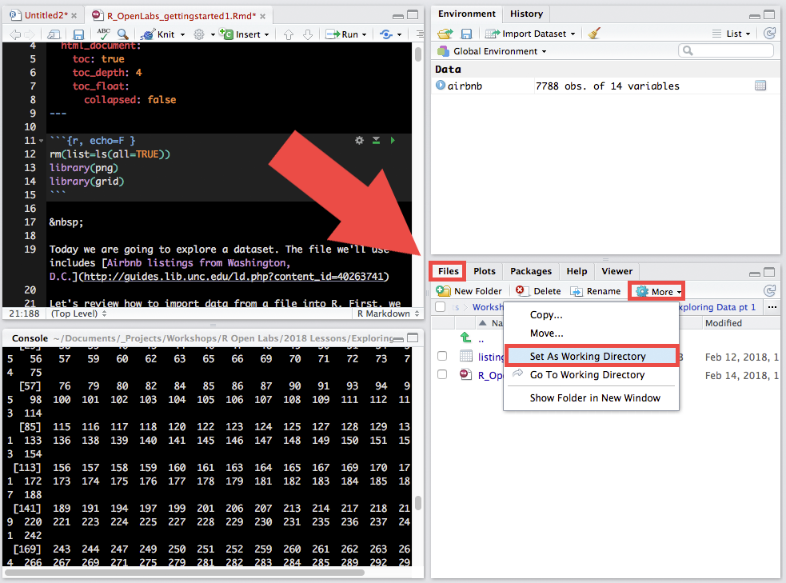

If you struggle with correctly typing in the path to your working directory, this shortcut can be very helpful!

Now we need to read the file into R. It’s a CSV file, so we’ll use `read.csv()` to create a **dataframe object** called airbnb.

```r
airbnb <- read.csv("listings.csv")
```

Look at your **Environment** pane in the upper right of R Studio. It should tell you that our dataframe has **7,788 observations**. That’s a lot! Simply looking at the records in our dataset will not provide us with very good information about what’s going on. We’ll need to use some functions in R to explore and find patterns in the data.

## Exploring Structure

We have previously used the `str()` function to examine the structure of our dataset and see what storage types R is using for our different variables. Let’s do that with our Airbnb listings.

```r
str(airbnb)
```

```
'data.frame':   7788 obs. of  14 variables:
 $ id                  : int  4873463 16736650 14999877 5955860 15655208 4022565 15968425 1301700 646183 14769106 ...
 $ name                : Factor w/ 7721 levels ""," Great Studio in Heart of Dupont!",..: 2689 4462 5377 6594 4845 3189 2472 3195 398 6462 ...
 $ property_type       : Factor w/ 22 levels "Apartment","Bed & Breakfast",..: 1 1 1 1 19 1 1 1 1 1 ...
 $ room_type           : Factor w/ 3 levels "Entire home/apt",..: 1 1 1 1 1 2 1 1 1 2 ...
 $ accommodates        : int  3 2 2 3 4 2 3 2 4 2 ...
 $ bathrooms           : num  1 1 1 1 2.5 2.5 1 1 1 1 ...
 $ bedrooms            : int  0 0 1 1 2 1 1 1 2 1 ...
 $ price               : num  95 200 100 129 500 110 225 79 172 110 ...
 $ extra_people        : num  10 0 0 50 0 15 20 0 0 10 ...
 $ minimum_nights      : int  2 1 27 2 2 6 3 3 1 1 ...
 $ number_of_reviews   : int  29 2 0 79 1 7 3 4 24 4 ...
 $ review_scores_rating: int  94 90 NA 85 100 97 100 89 88 100 ...
 $ cancellation_policy : Factor w/ 4 levels "flexible","moderate",..: 1 1 2 1 3 3 1 1 1 2 ...
 $ reviews_per_month   : num  1.01 0.55 NA 3.13 1 0.23 0.82 0.09 0.48 0.67 ...
```

We can see that our dataset contains a mixture of factor, integer, and numeric variables. One factor is **property_type**. What are all the property types in this dataset? We know the `levels()` function can give us that information.

```r
levels(airbnb$property_type)
```

```
 [1] "Apartment"          "Bed & Breakfast"    "Boat"
 [4] "Boutique hotel"     "Bungalow"           "Cabin"
 [7] "Castle"             "Condominium"        "Dorm"
[10] "Guest suite"        "Guesthouse"         "Hostel"
[13] "House"              "In-law"             "Loft"
[16] "Other"              "Serviced apartment" "Timeshare"
[19] "Townhouse"          "Train"              "Treehouse"
[22] "Villa"
```

How many records have a property type listed? The `length()` function tells us how many items are in an object.

```r
length(airbnb$property_type)
```

```
[1] 7788
```

7,788 is the same as the total number of observations in our dataset, which means that none of our listings are missing property type information. That’s good to know! What if we want to know how many listings are for apartments? We can use the `which()` function to focus in on a particular factor level.

Notice the **double equal sign** used below. In many programming languages, we use a single equal sign to **assign** a value and a double equal sign to **check** a value. In this case, we’re *checking* to see if property_type *is equal to* “Apartment”.

```r
which(airbnb$property_type == "Apartment")
```

```
  [1]   1   2   3   4   6   7   8   9  10  11  12  13  16  17  19  21  23
 [18]  25  26  27  29  31  32  33  34  35  36  37  38  39  40  43  44  46
 [35]  47  48  49  50  51  54  55  56  57  59  60  62  63  65  66  69  70
 [52]  71  72  73  74  75  76  79  80  82  84  85  86  87  90  91  93  94
 [69]  95  98 100 101 102 103 104 105 106 107 108 109 111 112 113 114 115
 [86] 116 117 118 120 122 123 124 125 127 128 129 131 133 136 138 139 140
[103] 141 145 146 147 148 149 150 151 153 154 156 157 158 159 160 161 163
[120] 164 165 167 169 170 171 172 173 174 175 176 177 178 179 181 182 183
[137] 184 185 187 188 189 191 194 197 199 201 206 207 213 214 217 218 219
[154] 220 221 223 224 225 227 228 229 230 231 235 236 237 241 242 243 244
[171] 247 249 250 251 252 259 260 261 262 263 264 266 267 269 271 275 279
[188] 281 282 283 284 285 289 292 293 294 295 296 299 302
 [ reached getOption("max.print") -- omitted 3991 entries ]
```

Yikes! R is trying to show us all of the row numbers for records that have an apartment property type. That’s not exactly helpful. We need to combine both `length()` and `which()` if we want to **count** all the rows that have an apartment property type. We can do that by **nesting functions** inside of each other.

```r
length(which(airbnb$property_type == "Apartment"))
```

```
[1] 4191
```

Now we can see that 4,191 listings are for apartments. But what if we want to look at the total number of listings for **every** property type? Do we need to type out the `length()` and `which()` functions for each level? Fortunately not! Instead, we can use **tables**.

## Tables

Tables will give you a total record count for all the levels of a factor.

```r
table(airbnb$property_type)
```

```
         Apartment    Bed & Breakfast               Boat
              4191                 73                  3
    Boutique hotel           Bungalow              Cabin
                11                  4                  1
            Castle        Condominium               Dorm
                 1                420                 25
       Guest suite         Guesthouse             Hostel
                11                 17                  2
             House             In-law               Loft
              2480                 12                 33
             Other Serviced apartment          Timeshare
                31                  1                  1
         Townhouse              Train          Treehouse
               468                  1                  1
             Villa
                 1
```

If we’re particularly interested in the most common and least common property types, we can nest the `table()` function inside the `sort()` function.

```r
sort(table(airbnb$property_type), decreasing=TRUE)
```

```
         Apartment              House          Townhouse
              4191               2480                468
       Condominium    Bed & Breakfast               Loft
               420                 73                 33
             Other               Dorm         Guesthouse
                31                 25                 17
            In-law     Boutique hotel        Guest suite
                12                 11                 11
          Bungalow               Boat             Hostel
                 4                  3                  2
             Cabin             Castle Serviced apartment
                 1                  1                  1
         Timeshare              Train          Treehouse
                 1                  1                  1
             Villa
                 1
```

We can also use the table function to provide logical answers to questions such as, “How many places charge more than $500 a night?”

```r
table(airbnb$price > 500)
```

```
FALSE  TRUE
 7029   759
```

For 759 listings, it’s TRUE that the price is greater than $500 a night. We can even use `table()` to break those results down by property type.

```r
table(airbnb$property_type, airbnb$price > 500)
```

```
                     FALSE TRUE
  Apartment           3884  307
  Bed & Breakfast       72    1
  Boat                   3    0
  Boutique hotel        11    0
  Bungalow               4    0
  Cabin                  1    0
  Castle                 1    0
  Condominium          356   64
  Dorm                  25    0
  Guest suite           11    0
  Guesthouse            16    1
  Hostel                 2    0
  House               2150  330
  In-law                12    0
  Loft                  28    5
  Other                 28    3
  Serviced apartment     1    0
  Timeshare              1    0
  Townhouse            420   48
  Train                  1    0
  Treehouse              1    0
  Villa                  1    0
```

Tables are great for counting numbers of records or **frequencies**, but if we want to look at other metrics, we need to use `aggregate()`.

## Aggregating

Here’s another question we can ask about our dataset: what is the average price for each property type? The `aggregate()` function can help us answer that question.

The important arguments of `aggregate` are `by` and `FUN`. The `by` argument allows us to specify the variables we want to aggregate by, and the `FUN` argument specifies the function we want to use to aggregate them.

Again, our question is: what is the average price for each property type? To answer that question, we want to aggregate the **prices** in our dataset by **property type**, using the `mean()` function. It looks like this:

```r
aggregate(airbnb$price, by=list(airbnb$property_type),  FUN=mean)
```

```
              Group.1         x
1           Apartment 212.53066
2     Bed & Breakfast 155.06849
3                Boat  82.66667
4      Boutique hotel 177.18182
5            Bungalow 131.25000
6               Cabin 110.00000
7              Castle 199.00000
8         Condominium 292.07143
9                Dorm  42.44000
10        Guest suite  84.27273
11         Guesthouse 144.17647
12             Hostel  36.00000
13              House 305.66653
14             In-law  94.66667
15               Loft 289.66667
16              Other 218.25806
17 Serviced apartment 135.00000
18          Timeshare 500.00000
19          Townhouse 247.89316
20              Train 170.00000
21          Treehouse  25.00000
22              Villa 160.00000
```

Notice the `by` argument allows for a **list**. This means we can break our information down by more than one variable at a time if we want. For example, what if we wanted to know the average prices of room types BY property types?

```r
aggregate(airbnb$price, by=list(airbnb$room_type, airbnb$property_type),  FUN=mean)
```

```
           Group.1            Group.2         x
1  Entire home/apt          Apartment 233.02819
2     Private room          Apartment 121.27288
3      Shared room          Apartment  61.35294
4  Entire home/apt    Bed & Breakfast 358.14286
5     Private room    Bed & Breakfast 134.73846
6      Shared room    Bed & Breakfast  55.00000
7  Entire home/apt               Boat  84.00000
8     Private room               Boat  80.00000
9     Private room     Boutique hotel 177.18182
10 Entire home/apt           Bungalow 165.00000
11    Private room           Bungalow  30.00000
12 Entire home/apt              Cabin 110.00000
13 Entire home/apt             Castle 199.00000
14 Entire home/apt        Condominium 345.63087
```

[output cut: 28 more lines]

## Correlation

R has many functions dedicated to performing complex statistical tests. However, when we’re first exploring our dataset, we may just want to take a quick glance at correlations between numeric variables. We can do that using the `cor()` function.

To find a Pearson’s correlation coefficient between price and number of reviews, we can do this:

```r
cor(airbnb$price, airbnb$number_of_reviews)
```

```
[1] -0.1560021
```

This indicates a very small negative linear correlation between price and number of reviews, but it doesn’t speak to the signifigance of that correlation. To look at p-values and confidence intervals, we need to use `cor.test`.

```r
cor.test(airbnb$price, airbnb$number_of_reviews)
```

```
    Pearson's product-moment correlation

data:  airbnb$price and airbnb$number_of_reviews
t = -13.936, df = 7786, p-value < 2.2e-16
alternative hypothesis: true correlation is not equal to 0
95 percent confidence interval:
 -0.1775967 -0.1342574
sample estimates:
       cor
-0.1560021
```

## Summary Statistics

If we are looking for basic summary statistics on the variables in our dataset, there’s an easy way to get them for each and every variable at once using the `summary()` function. For factors, `summary()` displays frequencies, and for numeric variables, it displays the minimum, 1st quartile, median, mean, 3rd quartile and maximum.

```r
summary(airbnb)
```

```
       id                                                        name
 Min.   :    2476                                                  :   5
 1st Qu.: 7001839   Capitol Hill Rowhouse                          :   3
 Median :13390319   Historic Capitol Hill Home                     :   3
 Mean   :11508399   Lux 1 Bedroom near White House w/wifi          :   3
 3rd Qu.:16404200   Lux 1 Bedroom Newseum Apt on the Mall          :   3
 Max.   :18670793   Lux 2 Bedroom Apt w/wifi near Convention Center:   3
                    (Other)                                        :7768
         property_type            room_type     accommodates
 Apartment      :4191   Entire home/apt:5326   Min.   : 1.000
 House          :2480   Private room   :2262   1st Qu.: 2.000
 Townhouse      : 468   Shared room    : 200   Median : 3.000
 Condominium    : 420                          Mean   : 3.584
 Bed & Breakfast:  73                          3rd Qu.: 4.000
 Loft           :  33                          Max.   :16.000
 (Other)        : 123
   bathrooms        bedrooms          price         extra_people
 Min.   :0.000   Min.   : 0.000   Min.   :   0.0   Min.   :  0.0
 1st Qu.:1.000   1st Qu.: 1.000   1st Qu.:  85.0   1st Qu.:  0.0
 Median :1.000   Median : 1.000   Median : 125.0   Median :  0.0
 Mean   :1.335   Mean   : 1.351   Mean   : 247.1   Mean   : 11.3
 3rd Qu.:1.500   3rd Qu.: 2.000   3rd Qu.: 249.0   3rd Qu.: 20.0
 Max.   :8.000   Max.   :10.000   Max.   :6000.0   Max.   :300.0
 NA's   :14      NA's   :14
 minimum_nights    number_of_reviews review_scores_rating
 Min.   :  1.000   Min.   :  0.00    Min.   : 20.00
 1st Qu.:  1.000   1st Qu.:  0.00    1st Qu.: 93.00
 Median :  2.000   Median :  5.00    Median : 97.00
 Mean   :  2.862   Mean   : 19.55    Mean   : 94.72
 3rd Qu.:  3.000   3rd Qu.: 21.00    3rd Qu.:100.00
 Max.   :200.000   Max.   :495.00    Max.   :100.00
                                     NA's   :2207
      cancellation_policy reviews_per_month
 flexible       :2816     Min.   : 0.010
 moderate       :2153     1st Qu.: 0.390
 strict         :2743     Median : 1.190
 super_strict_30:  76     Mean   : 2.003
                          3rd Qu.: 3.000
                          Max.   :21.350
                          NA's   :2128
```

## Exercises

**Note: If you are completing exercises to obtain a badge, please *show your work* instead of providing just the answers.**

1. What are the different types of cancellation policies offered at Airbnb?
2. What is the most common and least common cancellation policy?
3. What percent of Airbnb property types are houses? *Hint: To find what percent of X is Y, use this formula: Y/X * 100*
4. How many listings get a review rating below 50?
5. What is the maximum number of people that can be accomodated at each property type? *Hint: For `aggregate()`, we can look at other statistics than just the mean. Another option is “max” which gives us the highest value at each level.*

## [Let us know what you think of this lesson!](https://unc.az1.qualtrics.com/jfe/form/SV_8e1zRY2rlFUYBMx)